# Immigrant Australia 1970-1979

Matti Munk Nielsen

11 May 2024

# Download

## Library

```r
library(tidyverse)
```

```r
library(tidytext)
library(ggwordcloud)
```

## Read the csv.file

```r
Immigrant_1970_1979 <- read_csv("Immigrant_Australia_1970-1979.csv")
```

## Show csv.file

```r
Immigrant_1970_1979
```

```
## # A tibble: 100 × 14
##    article_text     article_id article_URL article_heading category article_date
##    <chr>                 <dbl> <chr>       <chr>           <chr>    <date>
##  1 migrant GLASGOW…  116340086 https://ap… Immigrant       Article  1975-03-28
##  2 Immigrant child…  262521765 https://ap… Immigrant chil… Article  1977-06-10
##  3 Immigrant reque…  263134352 https://ap… Immigrant requ… Article  1971-11-25
##  4 New immigrant  …  263239396 https://ap… New immigrant   Article  1979-02-15
##  5 IMMIGRANT CITAT…  263243015 https://ap… IMMIGRANT CITA… Article  1975-12-18
##  6 Unusual Immigra…  262485995 https://ap… Unusual Immigr… Article  1970-04-24
##  7 Immigrant group…  131857027 https://ap… Immigrant grou… Article  1978-06-05
##  8 IMMIGRANT COUNC…  263204445 https://ap… IMMIGRANT COUN… Article  1974-04-18
##  9 1 l V e .. . im…  263234270 https://ap… ... immigrant … Article  1978-10-26
## 10 Immigrant amnes…  110799059 https://ap… Immigrant amne… Article  1976-01-26
## # ℹ 90 more rows
## # ℹ 8 more variables: article_page <dbl>, article_page_sequence <chr>,
## #   article_Trove_URL <chr>, article_snippet <chr>, article_title_id <dbl>,
## #   article_title_title <chr>, article_relevance_score <dbl>,
## #   article_relevance_value <chr>
```

# Textmining

## Unnest tokens

Unnest tokens separates individual words from the articles in a column.

```r
Immigrant_1970_1979_tokens <-Immigrant_1970_1979 %>%
  unnest_tokens(word,article_text)

Immigrant_1970_1979_tokens
```

```
## # A tibble: 30,904 × 14
##    article_id article_URL     article_heading category article_date article_page
##         <dbl> <chr>           <chr>           <chr>    <date>              <dbl>
##  1  116340086 https://api.tr… Immigrant       Article  1975-03-28             11
##  2  116340086 https://api.tr… Immigrant       Article  1975-03-28             11
##  3  116340086 https://api.tr… Immigrant       Article  1975-03-28             11
##  4  116340086 https://api.tr… Immigrant       Article  1975-03-28             11
##  5  116340086 https://api.tr… Immigrant       Article  1975-03-28             11
##  6  116340086 https://api.tr… Immigrant       Article  1975-03-28             11
##  7  116340086 https://api.tr… Immigrant       Article  1975-03-28             11
##  8  116340086 https://api.tr… Immigrant       Article  1975-03-28             11
##  9  116340086 https://api.tr… Immigrant       Article  1975-03-28             11
## 10  116340086 https://api.tr… Immigrant       Article  1975-03-28             11
## # ℹ 30,894 more rows
## # ℹ 8 more variables: article_page_sequence <chr>, article_Trove_URL <chr>,
## #   article_snippet <chr>, article_title_id <dbl>, article_title_title <chr>,
## #   article_relevance_score <dbl>, article_relevance_value <chr>, word <chr>
```

## Count words

```r
Immigrant_1970_1979_wc <- Immigrant_1970_1979_tokens%>%
  count(word)%>%
  arrange(-n)
```

## Stopwordslist

A stopwordslist is a list of all the stopwords in all the 100 articles.

```r
Immigrant_1970_1979_wc
```

```
## # A tibble: 8,118 × 2
##    word      n
##    <chr> <int>
##  1 the    1262
##  2 in      824
##  3 of      728
##  4 and     559
##  5 de      537
##  6 a       509
##  7 to      507
##  8 van     308
##  9 is      290
## 10 en      264
## # ℹ 8,108 more rows
```

## Remove stopwordslist

```r
Immigrant_1970_1979_stop <- Immigrant_1970_1979_tokens%>%
  anti_join(stop_words)
Immigrant_1970_1979_stop
```

```
## # A tibble: 18,872 × 14
##    article_id article_URL     article_heading category article_date article_page
##         <dbl> <chr>           <chr>           <chr>    <date>              <dbl>
##  1  116340086 https://api.tr… Immigrant       Article  1975-03-28             11
##  2  116340086 https://api.tr… Immigrant       Article  1975-03-28             11
##  3  116340086 https://api.tr… Immigrant       Article  1975-03-28             11
##  4  116340086 https://api.tr… Immigrant       Article  1975-03-28             11
##  5  116340086 https://api.tr… Immigrant       Article  1975-03-28             11
##  6  116340086 https://api.tr… Immigrant       Article  1975-03-28             11
##  7  116340086 https://api.tr… Immigrant       Article  1975-03-28             11
##  8  116340086 https://api.tr… Immigrant       Article  1975-03-28             11
##  9  116340086 https://api.tr… Immigrant       Article  1975-03-28             11
## 10  116340086 https://api.tr… Immigrant       Article  1975-03-28             11
## # ℹ 18,862 more rows
## # ℹ 8 more variables: article_page_sequence <chr>, article_Trove_URL <chr>,
## #   article_snippet <chr>, article_title_id <dbl>, article_title_title <chr>,
## #   article_relevance_score <dbl>, article_relevance_value <chr>, word <chr>
```

## Count words again

```r
Immigrant_1970_1979_swc <- Immigrant_1970_1979_stop%>%
  count(word)%>%
  arrange(-n)

Immigrant_1970_1979_swc
```

```
## # A tibble: 7,622 × 2
##    word          n
##    <chr>     <int>
##  1 de          537
##  2 van         308
##  3 en          264
##  4 het         186
##  5 een         176
##  6 immigrant   130
##  7 zijn        118
##  8 te          117
##  9 hij         109
## 10 israel       90
## # ℹ 7,612 more rows
```

## Show Immigrant 1970 to 1979 swc head

```r
 Immigrant_1970_1979_swc%>%
  head(10)
```

```
## # A tibble: 10 × 2
##    word          n
##    <chr>     <int>
##  1 de          537
##  2 van         308
##  3 en          264
##  4 het         186
##  5 een         176
##  6 immigrant   130
##  7 zijn        118
##  8 te          117
##  9 hij         109
## 10 israel       90
```

## Remove nontext

```r
Immigrant_1970_1979_no_numeric <- Immigrant_1970_1979_stop%>%
  filter(is.na(as.numeric(word)))
```

## View nontext

```r
Immigrant_1970_1979_no_numeric
```

```
## # A tibble: 18,439 × 14
##    article_id article_URL     article_heading category article_date article_page
##         <dbl> <chr>           <chr>           <chr>    <date>              <dbl>
##  1  116340086 https://api.tr… Immigrant       Article  1975-03-28             11
##  2  116340086 https://api.tr… Immigrant       Article  1975-03-28             11
##  3  116340086 https://api.tr… Immigrant       Article  1975-03-28             11
##  4  116340086 https://api.tr… Immigrant       Article  1975-03-28             11
##  5  116340086 https://api.tr… Immigrant       Article  1975-03-28             11
##  6  116340086 https://api.tr… Immigrant       Article  1975-03-28             11
##  7  116340086 https://api.tr… Immigrant       Article  1975-03-28             11
##  8  116340086 https://api.tr… Immigrant       Article  1975-03-28             11
##  9  116340086 https://api.tr… Immigrant       Article  1975-03-28             11
## 10  116340086 https://api.tr… Immigrant       Article  1975-03-28             11
## # ℹ 18,429 more rows
## # ℹ 8 more variables: article_page_sequence <chr>, article_Trove_URL <chr>,
## #   article_snippet <chr>, article_title_id <dbl>, article_title_title <chr>,
## #   article_relevance_score <dbl>, article_relevance_value <chr>, word <chr>
```

## Unique words

```r
length(unique(Immigrant_1970_1979_no_numeric$word))
```

```
## [1] 7482
```

## Top 100 words

Show the 100 most used words in all the 100 articles.

```r
Immigrant_1970_1979_top100 <- Immigrant_1970_1979_no_numeric%>%
  count(word)%>%
  arrange(-n)%>%
  head(100)

Immigrant_1970_1979_top100
```

```
## # A tibble: 100 × 2
##    word          n
##    <chr>     <int>
##  1 de          537
##  2 van         308
##  3 en          264
##  4 het         186
##  5 een         176
##  6 immigrant   130
##  7 zijn        118
##  8 te          117
##  9 hij         109
## 10 israel       90
## # ℹ 90 more rows
```

## Cloud

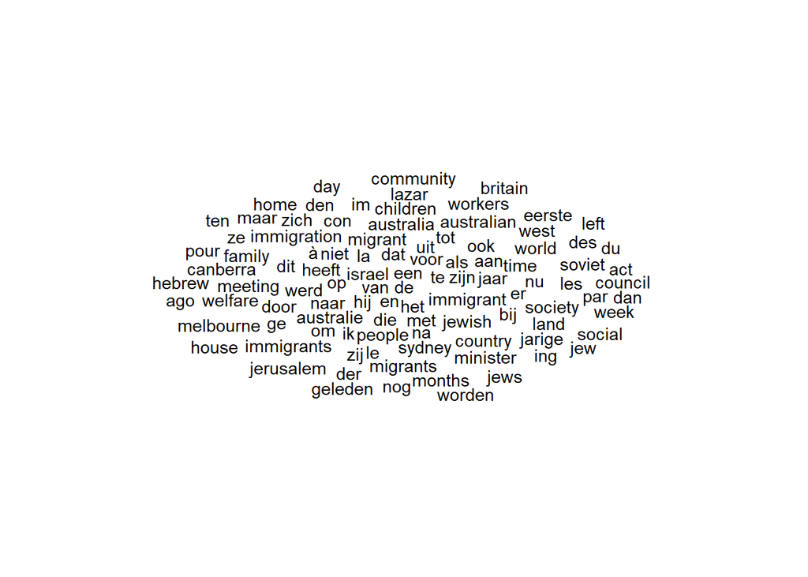

```r
Immigrant_1970_1979_cloud <- ggplot(data = Immigrant_1970_1979_top100, aes( label = word)) + geom_text_wordcloud() + theme_minimal()

Immigrant_1970_1979_cloud
```

## Customize cloud

Shows the most frequent used words from the 100 articles where green is most,then yellow and last pink.

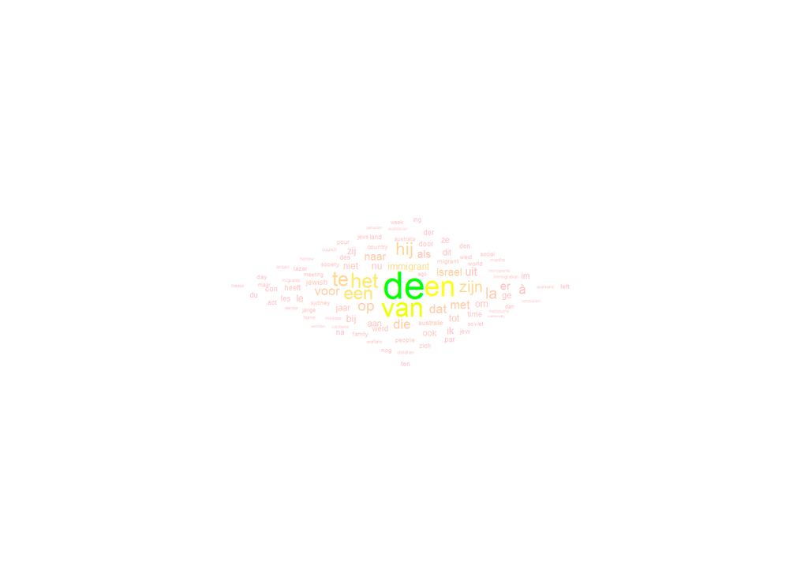

```r
ggplot(data = Immigrant_1970_1979_top100, aes(label = word, size = n)) +
  geom_text_wordcloud_area(aes(color = n), shape = "diamond") +
  scale_size_area(max_size = 12) +
  scale_color_gradientn(colors = c("pink", "yellow", "green")) +
  theme_minimal()
```

# Sentiment analysis

## Lexicon afinn

```r
get_sentiments(lexicon = "afinn")
```

```
## # A tibble: 2,477 × 2
##    word       value
##    <chr>      <dbl>
##  1 abandon       -2
##  2 abandoned     -2
##  3 abandons      -2
##  4 abducted      -2
##  5 abduction     -2
##  6 abductions    -2
##  7 abhor         -3
##  8 abhorred      -3
##  9 abhorrent     -3
## 10 abhors        -3
## # ℹ 2,467 more rows
```

```r
afinn_pos <- get_sentiments("afinn") %>%
  filter(value %in% c(3,4,5))
```

```r
afinn_pos
```

```
## # A tibble: 222 × 2
##    word         value
##    <chr>        <dbl>
##  1 admire           3
##  2 admired          3
##  3 admires          3
##  4 admiring         3
##  5 adorable         3
##  6 adore            3
##  7 adored           3
##  8 adores           3
##  9 affection        3
## 10 affectionate     3
## # ℹ 212 more rows
```

## Lexicon bing

```r
get_sentiments(lexicon = "bing")
```

```
## # A tibble: 6,786 × 2
##    word        sentiment
##    <chr>       <chr>
##  1 2-faces     negative
##  2 abnormal    negative
##  3 abolish     negative
##  4 abominable  negative
##  5 abominably  negative
##  6 abominate   negative
##  7 abomination negative
##  8 abort       negative
##  9 aborted     negative
## 10 aborts      negative
## # ℹ 6,776 more rows
```

## Lexicon nrc

```r
get_sentiments(lexicon = "nrc")
```

```
## # A tibble: 13,872 × 2
##    word        sentiment
##    <chr>       <chr>
##  1 abacus      trust
##  2 abandon     fear
##  3 abandon     negative
##  4 abandon     sadness
##  5 abandoned   anger
##  6 abandoned   fear
##  7 abandoned   negative
##  8 abandoned   sadness
##  9 abandonment anger
## 10 abandonment fear
## # ℹ 13,862 more rows
```

## Immigrant 1970 to 1979 afinn

Inner join connects the stopwords column(word) with the afinn column(value).

```r
Immigrant_1970_1979_afinn <-  Immigrant_1970_1979_stop%>%
  inner_join(get_sentiments("afinn"))
Immigrant_1970_1979_afinn
```

```
## # A tibble: 723 × 15
##    article_id article_URL     article_heading category article_date article_page
##         <dbl> <chr>           <chr>           <chr>    <date>              <dbl>
##  1  262521765 https://api.tr… Immigrant chil… Article  1977-06-10             23
##  2  262521765 https://api.tr… Immigrant chil… Article  1977-06-10             23
##  3  263134352 https://api.tr… Immigrant requ… Article  1971-11-25             12
##  4  263134352 https://api.tr… Immigrant requ… Article  1971-11-25             12
##  5  263134352 https://api.tr… Immigrant requ… Article  1971-11-25             12
##  6  263134352 https://api.tr… Immigrant requ… Article  1971-11-25             12
##  7  263243015 https://api.tr… IMMIGRANT CITA… Article  1975-12-18              9
##  8  263243015 https://api.tr… IMMIGRANT CITA… Article  1975-12-18              9
##  9  263243015 https://api.tr… IMMIGRANT CITA… Article  1975-12-18              9
## 10  262485995 https://api.tr… Unusual Immigr… Article  1970-04-24             10
## # ℹ 713 more rows
## # ℹ 9 more variables: article_page_sequence <chr>, article_Trove_URL <chr>,
## #   article_snippet <chr>, article_title_id <dbl>, article_title_title <chr>,
## #   article_relevance_score <dbl>, article_relevance_value <chr>, word <chr>,
## #   value <dbl>
```

## Immigrant 1970 to 1979 afinn hist

Counts the value of Immigrant 1970 to 1979 afinn.

```r
Immigrant_1970_1979_afinn_hist <- Immigrant_1970_1979_afinn%>%
  count(value)

Immigrant_1970_1979_afinn_hist
```

```
## # A tibble: 9 × 2
##   value     n
##   <dbl> <int>
## 1    -4     4
## 2    -3   138
## 3    -2   159
## 4    -1    97
## 5     1   120
## 6     2   153
## 7     3    40
## 8     4    11
## 9     5     1
```

## Plot immigrant 1970 to 1979 afinn hist

The x-axis(value) is the sentiment value where negative is shown as minus and positive with no minus and n is the amount of words that has the specific sentiment value from the x-axis(value).

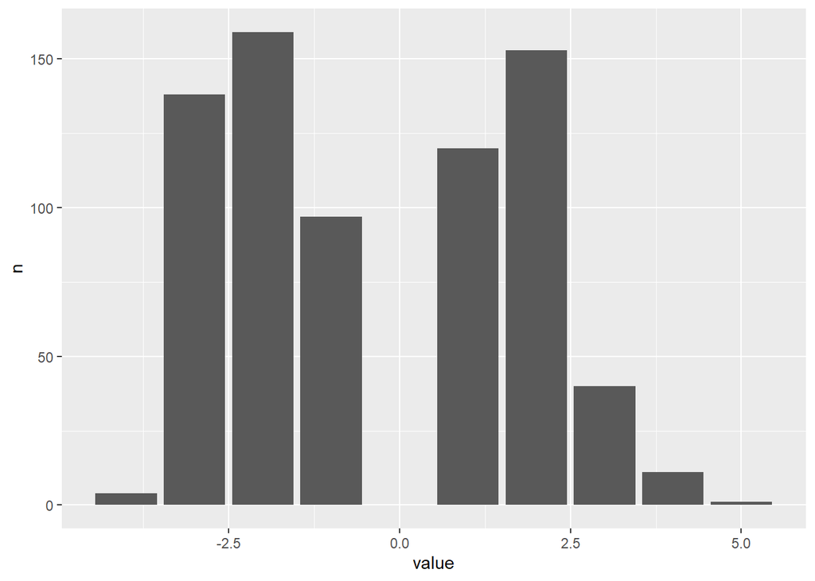

```r
ggplot(data = Immigrant_1970_1979_afinn_hist, aes(x = value, y = n)) +
  geom_col()
```

## Immigrant 1970 to 1979 afinn2

Here filter removes words that do not have a value on 2.

```r
Immigrant_1970_1979_afinn2 <- Immigrant_1970_1979_afinn %>%
  filter(value == 2)
```

## Unique 2 words score

```r
unique(Immigrant_1970_1979_afinn2$word)
```

```
##  [1] "ratified"        "noble"           "congratulations" "hope"
##  [5] "helping"         "support"         "optimism"        "assets"
##  [9] "fair"            "strong"          "competent"       "positively"
## [13] "gaining"         "asset"           "survived"        "true"
## [17] "chance"          "gained"          "chances"         "improve"
## [21] "bless"           "benefits"        "ability"         "improving"
## [25] "hoping"          "comprehensive"   "confidence"      "healthy"
## [29] "hail"            "freedom"         "opportunity"     "festive"
## [33] "astonished"      "comfort"         "boldly"          "saved"
## [37] "peace"           "willingness"     "meaningful"      "enjoy"
## [41] "benefit"         "gains"           "welcomed"        "privileged"
## [45] "top"             "smiling"         "satisfied"       "comfortable"
## [49] "enjoys"          "positive"        "smiled"          "improved"
## [53] "opportunities"   "effective"       "commitment"      "clean"
## [57] "eager"           "appreciation"    "prominent"       "worth"
## [61] "justified"       "importance"      "helpful"         "justice"
## [65] "exclusive"       "rich"            "competitive"     "solid"
## [69] "cleaner"         "calm"            "warmth"          "fine"
## [73] "approved"        "likes"           "worthy"          "respected"
## [77] "swiftly"         "gain"            "smile"           "hopes"
## [81] "proud"           "encouraged"      "care"            "bold"
## [85] "adventure"       "carefully"       "strengthens"     "helps"
## [89] "stable"          "success"
```

## Count plot Immigrant 1970 to 1979 afinn2 n

```r
Immigrant_1970_1979_afinn2_n<- Immigrant_1970_1979_afinn2%>%
  count(word, sort = TRUE) %>%
  mutate(word = fct_reorder(factor(word), n))

Immigrant_1970_1979_afinn2_n
```

```
## # A tibble: 90 × 2
##    word              n
##    <fct>         <int>
##  1 support           8
##  2 freedom           7
##  3 justice           6
##  4 top               5
##  5 enjoy             4
##  6 hope              4
##  7 true              4
##  8 chance            3
##  9 comprehensive     3
## 10 fine              3
## # ℹ 80 more rows
```

## Count and plot graph

The y-axis are words while the x-axis(n) is the amount of positivity in a word from the y-axis.

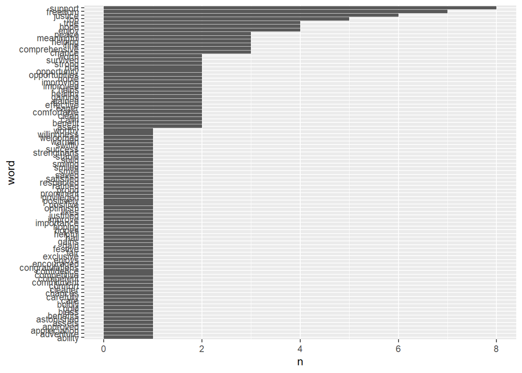

```r
ggplot(data = Immigrant_1970_1979_afinn2_n, aes(x = word, y = n)) +
  geom_col() +
  coord_flip()
```

## Summerize sentiment

```r
Immigrant_1970_1979_summery <- Immigrant_1970_1979_afinn%>%
  summarise(mean_score = mean(value), median_score = median(value))

Immigrant_1970_1979_summery
```

```
## # A tibble: 1 × 2
##   mean_score median_score
##        <dbl>        <dbl>
## 1     -0.346           -1
```

## Immigrant 1970 to 1979 nrc

Inner join connects the stopwords column(word) with the nrc column(sentiment).

```r
Immigrant_1970_1979_nrc <- Immigrant_1970_1979_stop%>%
  inner_join(get_sentiments("nrc"))
```

## Exclude

Anti join finds all words that do not match two dataframes.

```r
Immigrant_1970_1979_exclude <- Immigrant_1970_1979_stop %>%
  anti_join(get_sentiments("nrc"))
Immigrant_1970_1979_exclude
```

```
## # A tibble: 16,688 × 14
##    article_id article_URL     article_heading category article_date article_page
##         <dbl> <chr>           <chr>           <chr>    <date>              <dbl>
##  1  116340086 https://api.tr… Immigrant       Article  1975-03-28             11
##  2  116340086 https://api.tr… Immigrant       Article  1975-03-28             11
##  3  116340086 https://api.tr… Immigrant       Article  1975-03-28             11
##  4  116340086 https://api.tr… Immigrant       Article  1975-03-28             11
##  5  116340086 https://api.tr… Immigrant       Article  1975-03-28             11
##  6  116340086 https://api.tr… Immigrant       Article  1975-03-28             11
##  7  116340086 https://api.tr… Immigrant       Article  1975-03-28             11
##  8  116340086 https://api.tr… Immigrant       Article  1975-03-28             11
##  9  116340086 https://api.tr… Immigrant       Article  1975-03-28             11
## 10  116340086 https://api.tr… Immigrant       Article  1975-03-28             11
## # ℹ 16,678 more rows
## # ℹ 8 more variables: article_page_sequence <chr>, article_Trove_URL <chr>,
## #   article_snippet <chr>, article_title_id <dbl>, article_title_title <chr>,
## #   article_relevance_score <dbl>, article_relevance_value <chr>, word <chr>
```

## Count most exluded

```r
Immigrant_1970_1979_exclude_n <-  Immigrant_1970_1979_exclude%>%
  count(word, sort = TRUE)

Immigrant_1970_1979_exclude_n
```

```
## # A tibble: 6,778 × 2
##    word       n
##    <chr>  <int>
##  1 de       537
##  2 van      308
##  3 en       264
##  4 het      186
##  5 een      176
##  6 zijn     118
##  7 te       117
##  8 hij      109
##  9 israel    90
## 10 voor      84
## # ℹ 6,768 more rows
```

## Show Immigrant 1970-1979 exclude n head

```r
head(Immigrant_1970_1979_exclude_n)
```

```
## # A tibble: 6 × 2
##   word      n
##   <chr> <int>
## 1 de      537
## 2 van     308
## 3 en      264
## 4 het     186
## 5 een     176
## 6 zijn    118
```

## Emplot Immigrant 1970 to 1979 nrc n

The x-axis(sentiment) is the type of sentiment while the y-axis(n) is the amount of a sentiment from the x-axis.

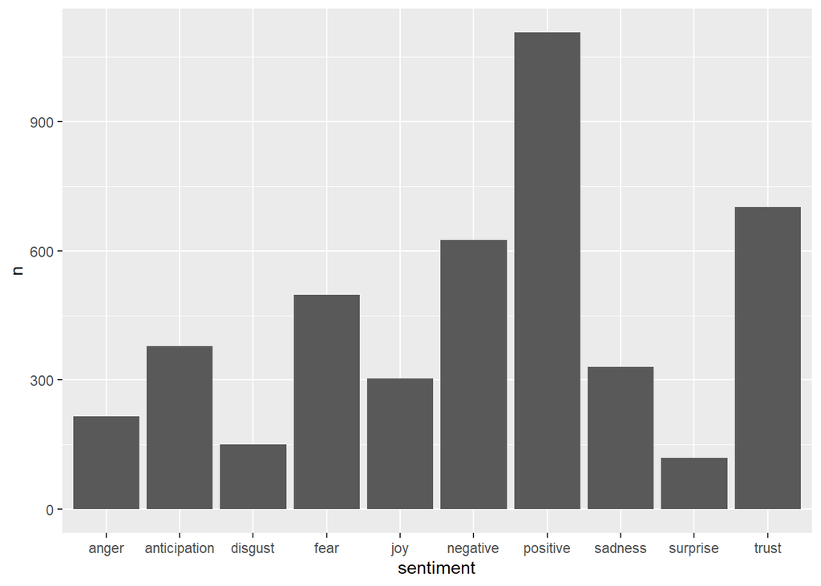

```r
Immigrant_1970_1979_nrc_n <- Immigrant_1970_1979_nrc %>%
  count(sentiment, sort = TRUE )

ggplot(data = Immigrant_1970_1979_nrc_n, aes(x = sentiment, y = n)) +
  geom_col()
```

## Count sentiment and word

There are multiple graphs each divided by a sentiment and each have a x-axis which represents the amount of sentiment to a specific word from the y-axis.

```r
Immigrant_1970_1979_nrc_n5 <- Immigrant_1970_1979_nrc %>%
  count(word,sentiment,sort = TRUE) %>%
  group_by(sentiment) %>%
  top_n(5) %>%
  ungroup()
```

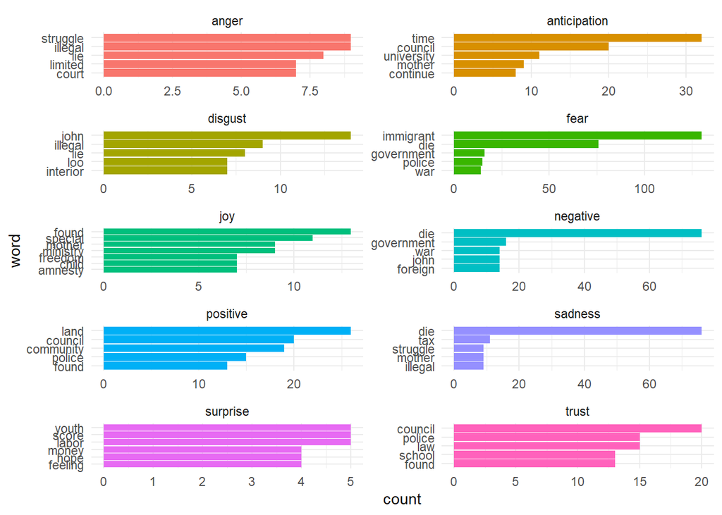

```r
Immigrant_1970_1979_nrc_gg <- ggplot(data = Immigrant_1970_1979_nrc_n5, aes(x = reorder(word,n), y = n, fill = sentiment)) +
  geom_col(show.legend = FALSE) +
  facet_wrap(~sentiment, ncol = 2, scales = "free") +
  coord_flip() +
  theme_minimal() +
  labs(x = "word" , y = "count")

Immigrant_1970_1979_nrc_gg
```

## Save it

```r
ggsave(plot = Immigrant_1970_1979_nrc_gg,
       filename ="figures/ipcc_nrc_sentiment.png",
      height = 8,
      width = 5)
```